# Huron River Watershed Council - A2 Data Dive 2017

Clayton Yochum

November 12, 2017

This document is an analysis of data provided by the Huron River Watershed Council as part of the 2017 A2 Data Dive.

Click the “Code” buttons above tables and plots to see the R code that generated them.

## Dam River Flow

We’ll start with pre-processed data measuring water flow below three dams on the Huron River. In order from north to south they are New Hudson, Hamburg, and Wall Street.

New Hudson has only daily readings and stops in 2014, but has no missing data. The other two have measurements in 15-minute intervals and have had some missing data imputed, while other gaps remain.

```r
dam_tbls <- list(
  `New Hudson`  = "../Huron River Watershed Council/Data/new_hudson_preprocessed.csv",
  `Hamburg`     = "../Huron River Watershed Council/Data/hamburg_preprocessed.csv",
  `Wall Street` = "../Huron River Watershed Council/Data/wall_street_preprocessed.csv"
) %>%
  map(
    read_csv,
    skip = 1,
    col_names = c("datetime", "flow"),
    col_types = "Td"
  ) %>%
  map(arrange, datetime)

dam_tbl <- dam_tbls %>%
  bind_rows(.id = "site") %>%
  mutate(site = factor(site, levels = names(dam_tbls)))

dam_tbl %>%
  group_by(site) %>%
  slice(c(1:3, (n() - 2):n())) %>%
  kable()
```

| site | datetime | flow |
| --- | --- | --- |
| New Hudson | 1990-01-01 00:00:00 | 109 |
| New Hudson | 1990-01-02 00:00:00 | 108 |
| New Hudson | 1990-01-03 00:00:00 | 108 |
| New Hudson | 2014-09-28 00:00:00 | 108 |
| New Hudson | 2014-09-29 00:00:00 | 104 |
| New Hudson | 2014-09-30 00:00:00 | 107 |
| Hamburg | 1990-01-03 00:00:00 | 212 |
| Hamburg | 1990-01-03 00:15:00 | 212 |
| Hamburg | 1990-01-03 00:30:00 | 212 |
| Hamburg | 2017-11-01 16:45:00 | 163 |
| Hamburg | 2017-11-01 17:00:00 | 163 |
| Hamburg | 2017-11-01 17:15:00 | 163 |
| Wall Street | 1990-01-01 00:00:00 | 358 |
| Wall Street | 1990-01-01 00:15:00 | 358 |
| Wall Street | 1990-01-01 00:30:00 | 333 |
| Wall Street | 2017-11-01 16:45:00 | 372 |
| Wall Street | 2017-11-01 17:00:00 | 372 |
| Wall Street | 2017-11-01 17:15:00 | 372 |

We can make sure the time intervals and endpoints match what we expect.

```r
dam_tbl %>%
  group_by(site) %>%
  summarize(
    start    = min(datetime),
    stop     = max(datetime),
    n        = n(),
    avg_flow = mean(flow)
  ) %>%
  kable()
```

| site | start | stop | n | avg_flow |
| --- | --- | --- | --- | --- |
| New Hudson | 1990-01-01 | 2014-09-30 00:00:00 | 9039 | 128.7847 |
| Hamburg | 1990-01-03 | 2017-11-01 17:15:00 | 871618 | 252.0428 |
| Wall Street | 1990-01-01 | 2017-11-01 17:15:00 | 959972 | 545.3998 |

Can we plot it?

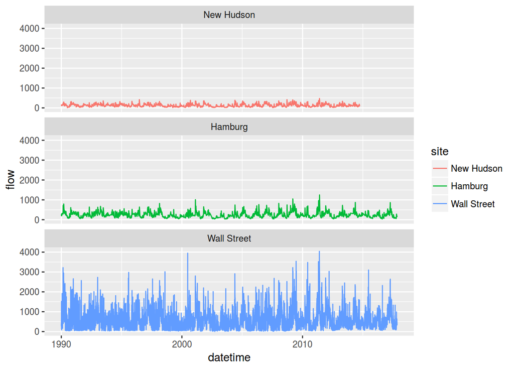

```r
dam_tbl %>%
  ggplot(aes(x = datetime, y = flow, color = site)) +
  facet_wrap(~site, ncol = 1) +
  geom_line()
```

We can also free the Y axis and add a smoothing line to get a sense of the baseline differences between sites.

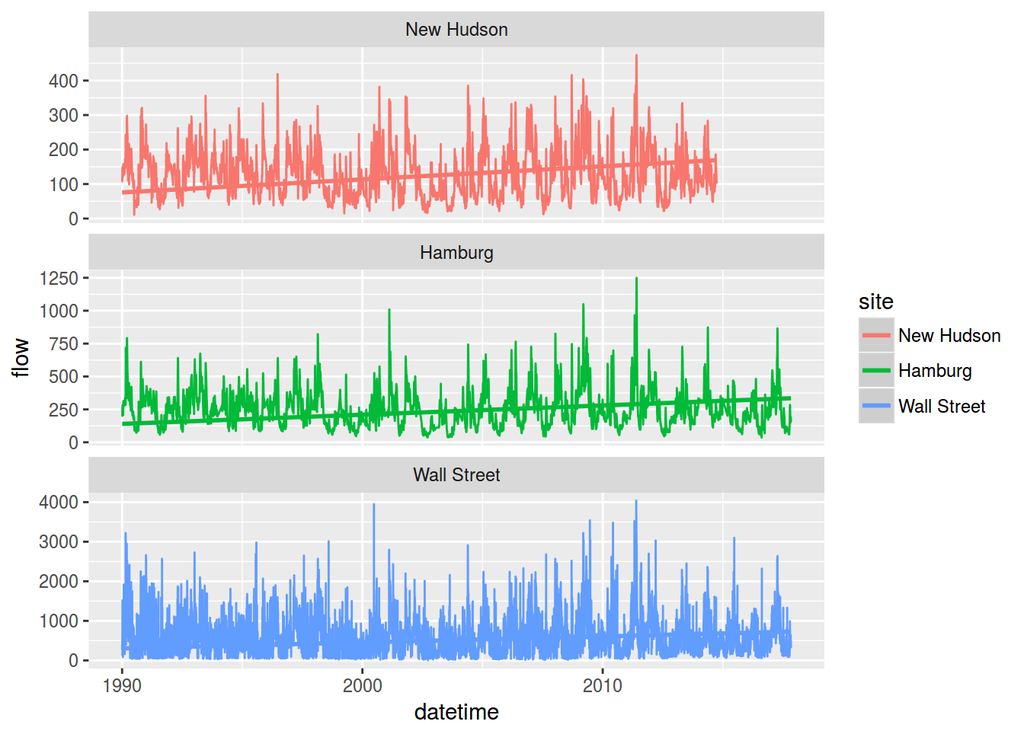

```r
dam_tbl %>%
  ggplot(aes(x = datetime, y = flow, color = site)) +
  geom_line() +
  geom_smooth(method = "gam") +
  facet_wrap(~site, ncol = 1, scales = "free_y")
```

While some missing values have been imputed for Hamburg and Wall Street, we’ll make remaining missing values explicit.

```r
dam_tbls <- dam_tbls %>%
  modify_at(
    c("Hamburg", "Wall Street"),
    ~ .x %>%
      complete(
        datetime = seq(min(.$datetime), max(.$datetime), by = as.difftime(15, units = "mins")),
        fill     = list(flow = NA_real_)
      )
  )

dam_tbl <- dam_tbls %>%
  bind_rows(.id = "site") %>%
  mutate(site = factor(site, levels = names(dam_tbls)))

dam_tbl %>%
  group_by(site) %>%
  summarize(
    start       = min(datetime),
    stop        = max(datetime),
    n           = n(),
    n_missing   = sum(is.na(flow)),
    pct_missing = n_missing / n,
    avg_flow    = mean(flow, na.rm = TRUE)
  ) %>%
  kable()
```

| site | start | stop | n | n_missing | pct_missing | avg_flow |
| --- | --- | --- | --- | --- | --- | --- |
| New Hudson | 1990-01-01 | 2014-09-30 00:00:00 | 9039 | 0 | 0.0000000 | 128.7847 |
| Hamburg | 1990-01-03 | 2017-11-01 17:15:00 | 975814 | 104196 | 0.1067785 | 252.0428 |
| Wall Street | 1990-01-01 | 2017-11-01 17:15:00 | 976006 | 16034 | 0.0164282 | 545.3998 |

We see a *lot* of missing data in Hamburg, over 10%!

### Rainfall

There’s also a set of rain gauge data from the Barton Pond, which is near the Wall Street gauge.

Rainfall is measured daily, in inches.

```r
rain_tbl <- read_csv(
  "../Huron River Watershed Council/Data/barton_pond_raingauge_data.csv",
  skip = 1,
  col_names = c("date", "rainfall"),
  col_types = "Dd"
)

rain_tbl %>%
  head() %>%
  kable()
```

| date | rainfall |
| --- | --- |
| 2009-11-24 | 0.00 |
| 2009-11-25 | 0.23 |
| 2009-11-26 | 0.04 |
| 2009-11-27 | 0.01 |
| 2009-11-28 | 0.00 |
| 2009-11-29 | 0.11 |

And a summary again

```r
rain_tbl %>%
  summarize(
    start     = min(date),
    stop      = max(date),
    n         = n(),
    n_missing = sum(is.na(rainfall)),
    avg_rain  = mean(rainfall)
  ) %>%
  kable()
```

| start | stop | n | n_missing | avg_rain |
| --- | --- | --- | --- | --- |
| 2009-11-24 | 2017-11-01 | 2900 | 0 | 0.0823 |

And a plot again

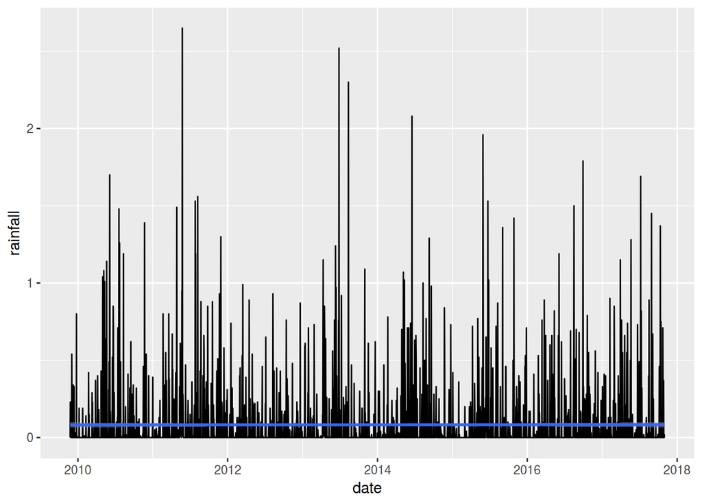

```r
rain_tbl %>%
  ggplot(aes(x = date, y = rainfall)) +
  geom_line() +
  geom_smooth(method = "gam")
```

## Main Questions

### Sudden Fluctuation in Flow

From the instructions (`General Instructions.pdf`):

> Sudden fluctuations are changes in flow by 150% or above within a 12 hour period.

Since New Hudson is measured in daily intervals, we’ll do this with the other two first.

```r
# 12 hours prior should be 12*4=48 points prior due to 15-minute interval
avg_flow_tbl <- dam_tbl %>%
  filter(site != "New Hudson") %>%
  group_by(site) %>%
  arrange(datetime) %>%
  mutate(
    lag = lag(flow, 1L),
    past_avg_flow = roll_meanr(lag,       48, na.rm = TRUE),
    past_missing  = roll_sumr(is.na(lag), 48)
  ) %>%
  ungroup() %>%
  select(-lag) %>%
  filter(!is.na(past_missing)) %>%                              # remove early entires without history
  mutate(pct_change = (flow - past_avg_flow) / past_avg_flow)

avg_flow_tbl %>%
  group_by(site) %>%
  slice(c(1:3, (n() - 2):n())) %>%
  kable()
```

| site | datetime | flow | past_avg_flow | past_missing | pct_change |
| --- | --- | --- | --- | --- | --- |
| Hamburg | 1990-01-03 11:45:00 | 208 | 211.0638 | 1 | -0.0145161 |
| Hamburg | 1990-01-03 12:00:00 | 210 | 211.0000 | 0 | -0.0047393 |
| Hamburg | 1990-01-03 12:15:00 | 210 | 210.9583 | 0 | -0.0045428 |
| Hamburg | 2017-11-01 16:45:00 | 163 | 162.7292 | 0 | 0.0016643 |
| Hamburg | 2017-11-01 17:00:00 | 163 | 162.7292 | 0 | 0.0016643 |
| Hamburg | 2017-11-01 17:15:00 | 163 | 162.7292 | 0 | 0.0016643 |
| Wall Street | 1990-01-01 11:45:00 | 353 | 345.9362 | 1 | 0.0204195 |
| Wall Street | 1990-01-01 12:00:00 | 363 | 346.0833 | 0 | 0.0488803 |
| Wall Street | 1990-01-01 12:15:00 | 363 | 346.1875 | 0 | 0.0485647 |
| Wall Street | 2017-11-01 16:45:00 | 372 | 380.8542 | 0 | -0.0232482 |
| Wall Street | 2017-11-01 17:00:00 | 372 | 380.7500 | 0 | -0.0229810 |
| Wall Street | 2017-11-01 17:15:00 | 372 | 380.6458 | 0 | -0.0227136 |

How many of our samples are more than 150% or 100% higher than the past 12-hour average?

```r
avg_flow_tbl %>%
  group_by(site) %>%
  summarize(
    n_over_150   = sum(pct_change >= 1.5, na.rm = TRUE),
    pct_over_150 = n_over_150 / n(),
    n_over_100   = sum(pct_change >= 1.0, na.rm = TRUE),
    pct_over_100 = n_over_100 / n()
  ) %>%
  kable()
```

| site | n_over_150 | pct_over_150 | n_over_100 | pct_over_100 |
| --- | --- | --- | --- | --- |
| Hamburg | 0 | 0.0000000 | 0 | 0.0000000 |
| Wall Street | 1768 | 0.0018116 | 4022 | 0.0041211 |

So we see there are no cases at the Hamburg site where flow was above 200% of the trailing 12-hour average, but there are a handful of such cases at the Wall Street site.

#### New Hudson

We can’t do quite the same calculation for New Hudson since it’s flow is only available per-day, but we can see which points are above the thresholds when compared to the prior days’ flow. This is a lot simpler to compute, and we also don’t have to sweat missing data.

```r
new_hudson_tbl <- dam_tbl %>%
  filter(site == "New Hudson") %>%
  arrange(datetime) %>%
  mutate(
    past_avg_flow = lag(flow, 1L),
    pct_change = (flow - past_avg_flow) / past_avg_flow
  ) %>%
  filter(!is.na(past_avg_flow))

new_hudson_tbl %>%
  summarize(
    n_over_150   = sum(pct_change >= 1.5),
    pct_over_150 = n_over_150 / n(),
    n_over_100   = sum(pct_change >= 1.0),
    pct_over_100 = n_over_100 / n()
  ) %>%
  kable()
```

| n_over_150 | pct_over_150 | n_over_100 | pct_over_100 |
| --- | --- | --- | --- |
| 5 | 0.0005532 | 18 | 0.0019916 |

So we see just a few days have a flow over the the thresholds compared to the previous day; might as well pull them all.

```r
new_hudson_tbl %>%
  filter(pct_change > 1.0) %>%
  arrange(desc(pct_change)) %>%
  kable()
```

| site | datetime | flow | past_avg_flow | pct_change |
| --- | --- | --- | --- | --- |
| New Hudson | 1990-09-07 | 151.0 | 50.0 | 2.020000 |
| New Hudson | 2001-04-14 | 66.0 | 24.0 | 1.750000 |
| New Hudson | 2011-07-28 | 121.0 | 46.1 | 1.624729 |
| New Hudson | 2007-08-20 | 79.0 | 30.9 | 1.556634 |
| New Hudson | 2012-08-10 | 110.0 | 43.9 | 1.505695 |
| New Hudson | 1999-11-08 | 162.0 | 65.0 | 1.492308 |
| New Hudson | 2005-11-14 | 104.0 | 42.9 | 1.424242 |
| New Hudson | 1996-04-21 | 89.0 | 38.0 | 1.342105 |
| New Hudson | 2008-09-14 | 262.0 | 112.0 | 1.339286 |
| New Hudson | 1998-11-02 | 138.0 | 59.0 | 1.338983 |
| New Hudson | 2005-11-01 | 142.0 | 63.0 | 1.253968 |
| New Hudson | 2000-04-20 | 58.0 | 27.0 | 1.148148 |
| New Hudson | 2007-07-27 | 55.7 | 26.0 | 1.142308 |
| New Hudson | 2001-07-30 | 102.0 | 48.0 | 1.125000 |
| New Hudson | 2006-09-13 | 88.9 | 43.2 | 1.057870 |
| New Hudson | 2004-12-22 | 128.0 | 63.2 | 1.025316 |
| New Hudson | 2003-10-31 | 157.0 | 78.4 | 1.002551 |

Plotting them might help show if this is a solved problem, or if these threshold-breaking increases still happen.

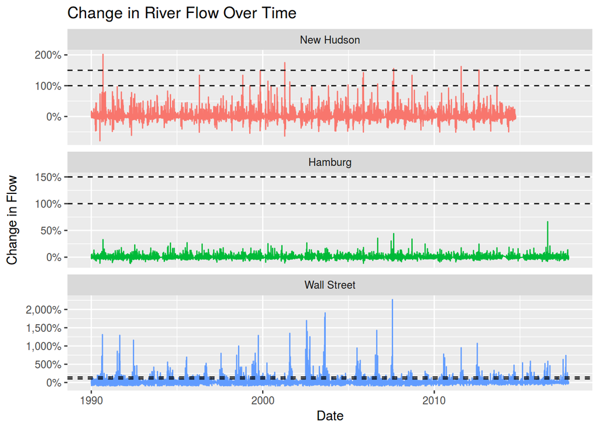

```r
avg_flow_tbl <- bind_rows(new_hudson_tbl, avg_flow_tbl)

avg_flow_tbl %>%
  filter(!is.na(pct_change)) %>%
  ggplot(aes(x = datetime, y = pct_change, color = site)) +
  facet_wrap(~site, ncol = 1, scales = "free_y") +
  geom_line() +
  geom_hline(yintercept = c(1, 1.5), linetype = 2) +
  labs(
    x = "Date",
    y = "Change in Flow",
    title = "Change in River Flow Over Time"
  ) +
  theme(legend.position = "none") +
  scale_y_continuous(labels = scales::percent)
```

### Flow Targets

The USGS sets targets for a minimum level of flow beyond each dam. How often do we dip below those?

```r
# manually extracted from "Example Numeric Flow Targets.docx"
flow_targets <- read_csv("../Huron River Watershed Council/Data/flow_targets.csv", col_types = "ciiii") %>%
  mutate(site = factor(site, levels = unique(site), labels = levels(dam_tbl$site)))

kable(flow_targets)
```

| site | base_flow | min_flow | spring_low_flow | spring_high_flow |
| --- | --- | --- | --- | --- |
| New Hudson | 58 | 46 | 60 | 284 |
| Hamburg | 154 | 124 | 155 | 651 |
| Wall Street | 272 | 218 | 307 | 1665 |

We can count how often we’re below the minimums

```r
dam_tbl <- dam_tbl %>%
  left_join(flow_targets, by = "site")

dam_tbl %>%
  filter(!is.na(flow)) %>%
  group_by(site) %>%
  summarize(
    n            = n(),
    n_low_flow   = sum(flow < min_flow),
    pct_low_flow = n_low_flow / n
  ) %>%
  kable()
```

| site | n | n_low_flow | pct_low_flow |
| --- | --- | --- | --- |
| New Hudson | 9039 | 783 | 0.0866246 |
| Hamburg | 871618 | 169229 | 0.1941550 |
| Wall Street | 959972 | 190867 | 0.1988256 |

Let’s plot our flows again, with the mininmum flow limits superimposed.

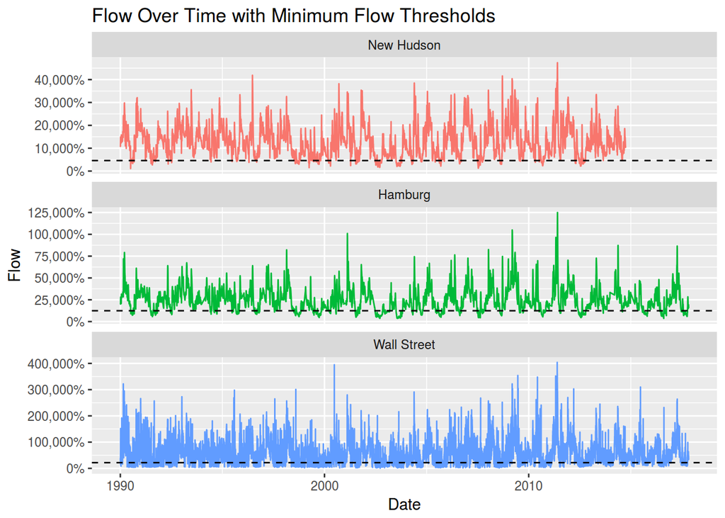

```r
dam_tbl %>%
  filter(!is.na(flow)) %>%
  ggplot(aes(x = datetime, y = flow, color = site)) +
  facet_wrap(~site, ncol = 1, scales = "free_y") +
  geom_line() +
  geom_hline(aes(yintercept = min_flow), linetype = 2) +
  labs(
    x = "Date",
    y = "Flow",
    title = "Flow Over Time with Minimum Flow Thresholds"
  ) +
  theme(legend.position = "none") +
  scale_y_continuous(labels = scales::percent)
```

That’s all I have so far; note some of this was cleaned up after the day of the actual data dive.

## What to do next

- Investigate yearly trends within each site
- Look at the other flow limits provided, the ones specific to the spring storm period
- Use the rainfall data to distinguish rain-driven spikes in flow from mand-made spikes due to dam operation
- Build a predictive model for future flow using historic flow data and rainfall